# Six-minute walk distance in adults with and without HIV

Dataset 11: HIV infection and exercise capacity

RSR feasibility analysis

2026-08-03

# Introduction

The Pittsburgh/UCSF lung-function study enrolled adults living with HIV and HIV-uninfected comparators from two US clinical centres and put every participant through the same battery: a six-minute walk test, spirometry, diffusing capacity for carbon monoxide and the St George’s Respiratory Questionnaire (Fitzpatrick and colleagues, *PLOS ONE* 2019). This teaching extract holds 427 participants, 297 of them living with HIV. Six-minute walk distance is a cheap, well-standardised measure of integrated cardiopulmonary and musculoskeletal function that predicts hospitalisation and death in chronic lung disease, and reduced exercise capacity is one of the more consistent reports in ageing HIV cohorts.

**Aim.** Among these adults, we examined which of HIV status, age, sex, current smoking, cumulative pack-years, blood pressure, haemoglobin and the three lung function measurements (FEV1, FVC and DLCO, each as a percentage of predicted) are independently associated with six-minute walk distance, mutually adjusting for the others.

This is a *Purpose 3* analysis: several predictors are of interest and the question is which remain associated with the outcome after mutual adjustment.

# Methods

**Data source.** A cross-sectional analysis of participants enrolled at two US clinical centres (Pittsburgh and San Francisco) into a cohort study of lung function in HIV. The extract contains 427 adults aged 21 to 79 and 21 variables; 297 (69.6%) are living with HIV and 130 are not. All measurements were made at a single study visit.

**Variables.** The outcome is `six_min_walk_m`, the distance in metres covered in a standardised six-minute walk test (observed range 61 to 774 m), treated as continuous. Predictors are HIV status (reference HIV-negative, the clinically unexposed group), age (years), sex (reference male, the larger group), current smoking (reference not a current smoker), cumulative smoking exposure (pack-years), systolic and diastolic blood pressure (mmHg), haemoglobin (g/dL), and FEV1, FVC and DLCO each expressed as a percentage of the predicted value for a person of the same age, sex and height.

**Smoking is entered once, as dose plus a current-smoking indicator.** The shipped `smoking_status` variable has three levels (never 132, former 106, current 189), and `pack_years` is **exactly zero for all 132 never-smokers and strictly positive for every ever-smoker**. The two variables therefore encode the same never/ever distinction twice, and putting the untouched factor alongside pack-years forces the former- and current-smoker contrasts to be estimated at zero pack-years, a value no ever-smoker in this sample has. We instead keep `pack_years` as the cumulative-dose term and add a single binary indicator for *current* smoking, which is the one piece of information pack-years cannot carry (current smoking has acute effects on carboxyhaemoglobin and airway inflammation that are independent of lifetime dose). This costs two parameters instead of three and imposes the sensible continuity assumption that a former smoker with negligible lifetime exposure resembles a never-smoker.

**Variables deliberately excluded.** `cd4_count`, `on_antiretroviral` and `viral_load_detectable` are **missing by design** for participants without HIV and are excluded from every model; the Feasibility notes below quantify what happens if they are not. `mmrc_dyspnoea` is excluded because it is missing for 111 participants, **all of them HIV-positive**, so it would delete a third of the exposed group. `fev1_fvc_ratio` is excluded because it is very largely a function of the two %-predicted values already in the model (regressing it on them gives R-squared 0.89). The three SGRQ subscales and the SGRQ total are downstream symptom reports rather than characteristics of the participant, and are analysed as outcomes elsewhere in this folder rather than used as predictors here.

**Statistical analysis.** `lm()`, justified because the outcome is a continuous distance in metres with a symmetric distribution (skewness -0.18). We fitted a univariable model for each predictor first, then a single multivariable model containing all of them. Predictors were chosen in advance on subject-matter grounds, not by significance: HIV status is the exposure of interest, and the remainder are the demographic, smoking, haemodynamic and lung-function characteristics that the source paper treats as determinants of walk distance. Significance threshold 0.05; estimates are reported with 95% confidence intervals. Assumptions were checked with `performance::check_model()`, with `check_collinearity()` inspected specifically because FEV1 and FVC are two readings from the same spirometry manoeuvre. Analysis used R version 4.6.0 (2026-04-24) with tidyverse, gtsummary and performance.

**Parameter budget.** The model estimates 11 parameters on 410 complete cases, i.e. about 37 observations per parameter, comfortably inside the 10-15 rule for a linear model. No cut to the suggested predictor list was needed.

**Missing data.** Complete-case analysis: 410 of 427 rows were analysed (17 dropped). The loss comes from haemoglobin (9 missing), spirometry (5 missing), blood pressure (3 missing) and DLCO (2 missing); the outcome itself is complete. The analytic sample retains 284 participants with HIV and 126 without, so the comparison the dataset exists for is essentially intact.

# Results

## Sample characteristics

**Table 1. Sample characteristics (complete-case analytic sample).**

| **Characteristic** | **N** | **N = 410**<sup>1</sup> |
| --- | --- | --- |
| Six-minute walk distance (m) | 410 | 445 (385, 491) |
| Living with HIV | 410 | 284 (69%) |
| Age (years) | 410 | 52 (45, 57) |
| Sex | 410 |  |
| Male |  | 254 (62%) |
| Female |  | 156 (38%) |
| Current smoker | 410 | 181 (44%) |
| Smoking (pack-years) | 410 | 7 (0, 23) |
| Systolic BP (mmHg) | 410 | 125 (115, 138) |
| Diastolic BP (mmHg) | 410 | 80 (72, 88) |
| Haemoglobin (g/dL) | 410 | 13.90 (12.70, 14.80) |
| FEV1 (% predicted) | 410 | 92 (78, 104) |
| FVC (% predicted) | 410 | 90 (80, 101) |
| DLCO (% predicted) | 410 | 81 (70, 91) |

<sup>1</sup> Median (Q1, Q3); n (%)

The sample is middle-aged (median age 52 years), predominantly male and heavily exposed to tobacco: about 44% are current smokers. Median walk distance is 445 m, with a wide spread from 61 to 774 m, and median lung function sits close to predicted for FEV1 and FVC but somewhat below predicted for DLCO (81% of predicted).

## Exploratory figure

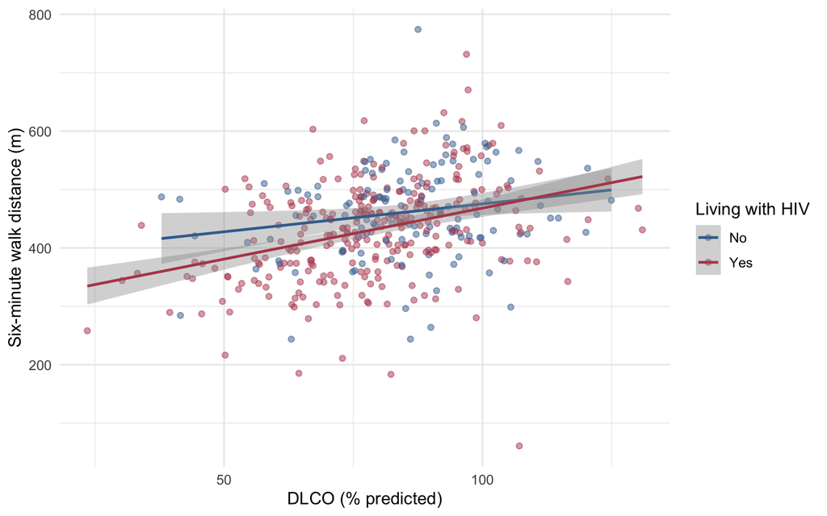

Figure 1. Six-minute walk distance against diffusing capacity, by HIV status.

## Univariable models

| **Characteristic** | **N** | **Beta** | **95% CI** | **p-value** |
| --- | --- | --- | --- | --- |
| Living with HIV | 410 |  |  |  |
| No |  | — | — |  |
| Yes |  | -31 | -48, -13 | <0.001 |
| Age (years) | 410 | -1.1 | -1.9, -0.31 | 0.007 |
| Sex | 410 |  |  |  |
| Male |  | — | — |  |
| Female |  | 4.6 | -12, 21 | 0.6 |
| Current smoker | 410 |  |  |  |
| No |  | — | — |  |
| Yes |  | -21 | -37, -4.4 | 0.013 |
| Smoking (pack-years) | 410 | -1.3 | -1.8, -0.81 | <0.001 |
| Systolic BP (mmHg) | 410 | -0.31 | -0.83, 0.21 | 0.2 |
| Diastolic BP (mmHg) | 410 | -0.18 | -0.96, 0.60 | 0.6 |
| Haemoglobin (g/dL) | 410 | 1.6 | -3.4, 6.6 | 0.5 |
| FEV1 (% predicted) | 410 | 1.6 | 1.2, 2.0 | <0.001 |
| FVC (% predicted) | 410 | 1.8 | 1.4, 2.3 | <0.001 |
| DLCO (% predicted) | 410 | 1.6 | 1.2, 2.1 | <0.001 |

Abbreviation: CI = Confidence Interval

Crudely, participants living with HIV walk less far than HIV-negative participants: -30.59 m (95% CI -48.15 to -13.02) (p <0.001), a deficit of about 31 m. All three lung-function measures show strong crude gradients: each additional percentage point of predicted FEV1 is worth 1.59 m (95% CI 1.20 to 1.98) (p <0.001), of predicted FVC 1.81 m (95% CI 1.35 to 2.27) (p <0.001) and of predicted DLCO 1.62 m (95% CI 1.16 to 2.08) (p <0.001). Smoking matters in both parameterisations: each pack-year is associated with -1.29 m (95% CI -1.77 to -0.81) (p <0.001), and current smokers walk shorter distances than non-current smokers, -20.83 m (95% CI -37.26 to -4.40) (p = 0.013). Each additional year of age is associated with -1.09 m (95% CI -1.87 to -0.31) (p = 0.007). Sex (4.56 m (95% CI -12.36 to 21.49), p = 0.596), blood pressure and haemoglobin show no crude association.

## Why adjustment is needed

**Cumulative smoking** is the clearest confounder of the HIV association. Participants with HIV in this sample have smoked more (mean 14.5 pack-years versus 11.4 in the HIV-negative group), and pack-years is itself one of the strongest crude predictors of walk distance (-1.29 m (95% CI -1.77 to -0.81) per pack-year). Some of the crude HIV deficit is therefore a tobacco deficit. **Diffusing capacity** is the second variable that must be handled explicitly: median DLCO is 79% of predicted in participants with HIV against 86% in those without, and DLCO is strongly related to walk distance, so it lies on the path between the two. Whether that makes it a confounder or a *mediator* is a genuine ambiguity: if HIV impairs gas transfer and impaired gas transfer shortens walk distance, then adjusting for DLCO removes part of the very effect we are trying to estimate, and the adjusted HIV coefficient should be read as the part of the HIV deficit *not* explained by measured lung function. **Sex** works on the smoking and haemoglobin coefficients rather than on HIV: men in this sample have higher haemoglobin (median 14.5 versus 12.8 g/dL) and different smoking histories, and sex also drives absolute walking capacity through stature and leg length. Mutual adjustment lets each coefficient be read as a comparison between participants alike on the other measured characteristics.

## Multivariable model

| **Characteristic** | **Beta** | **95% CI** | **p-value** |
| --- | --- | --- | --- |
| Living with HIV |  |  |  |
| No | — | — |  |
| Yes | -23 | -39, -6.2 | 0.007 |
| Age (years) | -0.19 | -0.99, 0.60 | 0.6 |
| Sex |  |  |  |
| Male | — | — |  |
| Female | -8.7 | -27, 9.7 | 0.4 |
| Current smoker |  |  |  |
| No | — | — |  |
| Yes | -8.6 | -25, 8.1 | 0.3 |
| Smoking (pack-years) | -0.65 | -1.2, -0.14 | 0.013 |
| Systolic BP (mmHg) | -0.40 | -1.0, 0.24 | 0.2 |
| Diastolic BP (mmHg) | 0.15 | -0.77, 1.1 | 0.8 |
| Haemoglobin (g/dL) | 2.4 | -3.0, 7.8 | 0.4 |
| FEV1 (% predicted) | 0.56 | -0.24, 1.4 | 0.2 |
| FVC (% predicted) | 0.85 | -0.08, 1.8 | 0.072 |
| DLCO (% predicted) | 0.63 | 0.08, 1.2 | 0.025 |

Abbreviation: CI = Confidence Interval

**Model fit: multivariable linear model for six-minute walk distance**

| Statistic | Value |
| --- | --- |
| Complete-case N | 410 |
| Parameters (excl. intercept) | 11 |
| Observations per parameter | 37.3 |
| R-squared | 0.215 |
| Adjusted R-squared | 0.193 |
| Residual SE (m) | 76.0 |

The model explains 21.5% of the variance in walk distance (adjusted R-squared 0.193), leaving a residual standard deviation of 76 m — larger than the whole HIV difference, so the model orders groups rather than individuals. Among participants of the same age, sex, smoking history, blood pressure, haemoglobin and lung function, those living with HIV still walk shorter distances, -22.76 m (95% CI -39.27 to -6.25) (p = 0.007), i.e. about 23 m less. Among participants alike on everything else, each additional pack-year is associated with -0.65 m (95% CI -1.17 to -0.14) (p = 0.013), so a 40 pack-year history corresponds to about 26 m. Diffusing capacity is the only lung-function measure that survives adjustment: 0.63 m (95% CI 0.08 to 1.18) per percentage point of predicted DLCO (p = 0.025), against 0.56 m (95% CI -0.24 to 1.35) for FEV1 (p = 0.169) and 0.85 m (95% CI -0.08 to 1.77) for FVC (p = 0.072). Age (-0.19 m (95% CI -0.99 to 0.60)), sex (-8.65 m (95% CI -27.05 to 9.75)), current smoking (-8.59 m (95% CI -25.27 to 8.09)), both blood pressures and haemoglobin are not independently associated. These are associations among the participants observed, not effects of intervening.

## Unadjusted versus adjusted

**Table 2. Unadjusted and adjusted estimates.**

| **Characteristic** | **Unadjusted** **N** | **Unadjusted** **Beta** | **Unadjusted** **95% CI** | **Unadjusted** **p-value** | **Adjusted** **Beta** | **Adjusted** **95% CI** | **Adjusted** **p-value** |
| --- | --- | --- | --- | --- | --- | --- | --- |
| Living with HIV | 410 |  |  |  |  |  |  |
| No |  | — | — |  | — | — |  |
| Yes |  | -31 | -48, -13 | <0.001 | -23 | -39, -6.2 | 0.007 |
| Age (years) | 410 | -1.1 | -1.9, -0.31 | 0.007 | -0.19 | -0.99, 0.60 | 0.6 |
| Sex | 410 |  |  |  |  |  |  |
| Male |  | — | — |  | — | — |  |
| Female |  | 4.6 | -12, 21 | 0.6 | -8.7 | -27, 9.7 | 0.4 |
| Current smoker | 410 |  |  |  |  |  |  |
| No |  | — | — |  | — | — |  |
| Yes |  | -21 | -37, -4.4 | 0.013 | -8.6 | -25, 8.1 | 0.3 |
| Smoking (pack-years) | 410 | -1.3 | -1.8, -0.81 | <0.001 | -0.65 | -1.2, -0.14 | 0.013 |
| Systolic BP (mmHg) | 410 | -0.31 | -0.83, 0.21 | 0.2 | -0.40 | -1.0, 0.24 | 0.2 |
| Diastolic BP (mmHg) | 410 | -0.18 | -0.96, 0.60 | 0.6 | 0.15 | -0.77, 1.1 | 0.8 |
| Haemoglobin (g/dL) | 410 | 1.6 | -3.4, 6.6 | 0.5 | 2.4 | -3.0, 7.8 | 0.4 |
| FEV1 (% predicted) | 410 | 1.6 | 1.2, 2.0 | <0.001 | 0.56 | -0.24, 1.4 | 0.2 |
| FVC (% predicted) | 410 | 1.8 | 1.4, 2.3 | <0.001 | 0.85 | -0.08, 1.8 | 0.072 |
| DLCO (% predicted) | 410 | 1.6 | 1.2, 2.1 | <0.001 | 0.63 | 0.08, 1.2 | 0.025 |

Abbreviation: CI = Confidence Interval

## Diagnostics

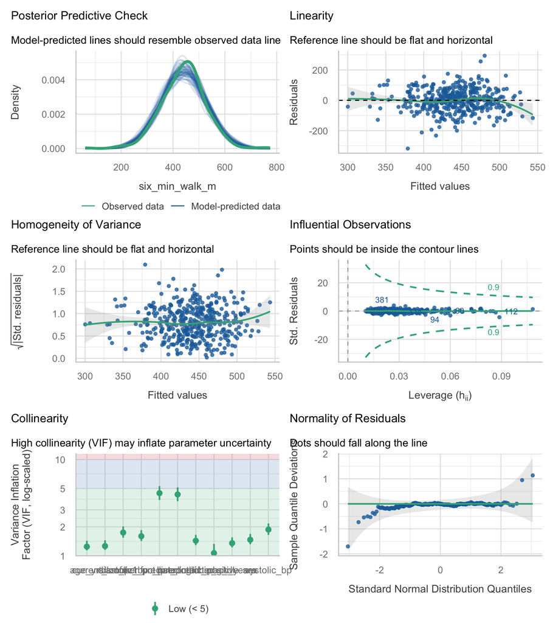

| Term | VIF | VIF_CI_low | VIF_CI_high | SE_factor | Tolerance | Tolerance_CI_low | Tolerance_CI_high |
| --- | --- | --- | --- | --- | --- | --- | --- |
| hiv_positive | 1.066724 | 1.013657 | 1.326007 | 1.032823 | 0.9374494 | 0.7541439 | 0.9865275 |
| age_yrs | 1.244511 | 1.138457 | 1.431799 | 1.115576 | 0.8035285 | 0.6984220 | 0.8783820 |
| sex | 1.467196 | 1.317378 | 1.687737 | 1.211279 | 0.6815721 | 0.5925093 | 0.7590838 |
| current_smoker | 1.261219 | 1.151576 | 1.450173 | 1.123040 | 0.7928836 | 0.6895730 | 0.8683750 |
| pack_years | 1.351871 | 1.223877 | 1.553042 | 1.162700 | 0.7397155 | 0.6438975 | 0.8170758 |
| systolic_bp | 1.870034 | 1.648347 | 2.167524 | 1.367492 | 0.5347495 | 0.4613560 | 0.6066686 |
| diastolic_bp | 1.743036 | 1.543642 | 2.015562 | 1.320241 | 0.5737117 | 0.4961396 | 0.6478186 |
| haemoglobin_g_dl | 1.433876 | 1.290252 | 1.648568 | 1.197446 | 0.6974104 | 0.6065871 | 0.7750422 |
| fev1_pct_predicted | 4.473169 | 3.805013 | 5.300481 | 2.114987 | 0.2235551 | 0.1886621 | 0.2628112 |
| fvc_pct_predicted | 4.338791 | 3.693570 | 5.138571 | 2.082977 | 0.2304789 | 0.1946066 | 0.2707408 |

[output cut: 1 more lines]

```
## OK: Error variance appears to be homoscedastic (p = 0.958).
```

The diagnostics are largely reassuring. The residual-versus-fitted panel is flat with no fanning and `check_heteroscedasticity()` does not reject constant variance (p = 0.958), which is expected for a bounded distance measure. The posterior-predictive check tracks the observed distribution closely. The normal-QQ panel is the one blemish: a handful of participants who walked very short distances sit well below the line, and `check_normality()` rejects normality (p = 0.004). With 410 observations this mild left tail has little practical consequence for the confidence intervals, and no transformation is indicated because the outcome itself is close to symmetric.

# Discussion

**Limitations.** Participants were recruited at **two clinical centres, Pittsburgh and UCSF, and the site variable is not in this deposit**, although the source paper shows that walk distance differs between them; site is therefore an unmeasured confounder and also a clustering variable that the model ignores, so the standard errors are very likely too small. The design is cross-sectional, so temporality is unknown and reverse causation is plausible for smoking, since people who cannot walk far may also be the people who continue to smoke. Adjusting for DLCO is probably adjusting for a *mediator* of the HIV effect rather than a confounder, which means the adjusted HIV coefficient is a “direct effect not through measured lung function” and understates the total association. Nothing about socioeconomic position, comorbidity, body composition, injecting drug use or musculoskeletal disease is measured, and all of these bear on how far someone walks. FEV1 and FVC compete for the same variance (VIFs 4.5 and 4.3), so neither spirometric coefficient should be interpreted on its own. Complete-case analysis dropped 17 of 427 rows (4.0%). Residuals are mildly non-normal in the left tail. All estimates are associations, not causal effects.

**Future work.** Refit with study site as a fixed effect and with body composition and comorbidity data from the parent cohort, and separate the total HIV association from the part mediated by diffusing capacity using a formal mediation analysis rather than a single adjusted coefficient.

# Feasibility notes

*NOT part of a student report.*

**Feasibility Table F1. Cost of adding an HIV-restricted variable to the model.**

| Added | N | HIV-negative retained | HIV-positive retained | HIV coefficient | p |
| --- | --- | --- | --- | --- | --- |
| (none - model as fitted) | 410 | 126 | 284 | -22.8 (SE 8.4) | 0.007 |
| cd4_count | 292 | 20 | 272 | -20.0 (SE 18.9) | 0.291 |
| on_antiretroviral | 284 | 0 | 284 | not estimable | model fails |
| viral_load_detectable | 271 | 0 | 271 | not estimable | model fails |
| mmrc_dyspnoea | 302 | 126 | 176 | -14.4 (SE 9.1) | 0.116 |

- **USABLE, and the best of the four outcomes in this dataset.** The outcome is complete (427/427), symmetric, clinically meaningful, and the exposure of interest survives adjustment. This is the outcome the source paper analysed and it behaves.
- **FATAL if any HIV-restricted variable is used as a predictor.** `cd4_count`, `on_antiretroviral` and `viral_load_detectable` exist only for participants with HIV. Feasibility Table F1 shows the damage precisely: adding `on_antiretroviral` or `viral_load_detectable` leaves **zero HIV-negative participants** (N falls from 410 to 284 and 271 respectively), so `hiv_positive` becomes a constant and `lm()` refuses to run at all (“contrasts can be applied only to factors with 2 or more levels”) — the comparison the dataset exists for has been deleted. A student who codes HIV status as 0/1 numeric instead of a factor gets no error at all, just a silent `NA` coefficient. Adding `cd4_count` is more insidious because it does not produce an obvious error: N falls to 292 and the HIV-negative group is cut from 126 to 20, the HIV coefficient’s standard error more than doubles, and the association goes from p = 0.007 to p = 0.291. A student would report “HIV was not associated with walk distance” and be wrong. This is the single most likely way this dataset is wrecked and it must be flagged in the brief.
- **MAJOR: `mmrc_dyspnoea` is differentially missing.** All 111 missing values are in HIV-positive participants (37% of that group, 0% of the HIV-negative group). Adding it drops N to 302 and the HIV coefficient loses significance (p = 0.116). It is also arguably a symptom consequence of low exercise capacity rather than a cause of it. Do not suggest it as a predictor.
- **MAJOR: FEV1 and FVC compete.** VIFs 4.47 and 4.34 (r = 0.87), against a maximum of 1.87 elsewhere. Below the threshold of 5 so no action is forced, but both crude associations (p <0.001 and p <0.001) disappear on adjustment purely for this reason. Students will misread that as “lung volumes don’t matter”.
- **MINOR: `pack_years` and `smoking_status` are structurally entangled.** `pack_years == 0` is exactly `smoking_status == "never"` on all 427 of 427 rows. Entering both untouched is estimable — VIFs 1.63 for `smoking_status` and 1.67 for `pack_years` — but the former/current contrasts are then evaluated at zero pack-years, which no ever-smoker has. The parameterisation used here (`pack_years` + current-smoker indicator) costs one parameter fewer and gives AIC 4728.1 against 4728.1 for the untouched three-level factor, i.e. no practical difference in fit and a cleaner interpretation. Either choice is defensible; silently using both without comment is not.
- **MINOR: non-normal residuals** (p = 0.004), a left tail from a small number of very poor walkers. Variance is constant (p = 0.958) and no transformation is warranted.
- **Complete-case N 410 of 427** (4.0% lost), matching the catalogue’s advertised 410/427 for the >= 95%-complete variable set. Confirmed for this predictor set.
- **On the `< 400 m` dichotomisation.** It works, but it is strictly worse. In the complete-case sample there are 121 events (29.5%) for 11 parameters, i.e. 11.0 events per parameter — right at the conventional minimum, with no room for a further covariate. The HIV odds ratio is 1.67 (95% CI 0.97 to 2.94, p = 0.067), i.e. **the association that is clearly significant on the linear scale is no longer significant after dichotomisation**, which is the standard power loss from throwing away a continuous outcome. Binned residuals also fail (65% inside the bounds against a 95% target). The catalogue is right to present this outcome as linear; the logistic version should be offered only as an explicit lesson in what dichotomisation costs.
- No separation issues arise (linear model), and no influential observations (max Cook’s distance 0.156).
- **Structural: two-site recruitment with no site variable.** The deposit does not carry Pittsburgh/UCSF. The model treats 410 participants as independent when they come from two centres with different populations, so standard errors are optimistic and site confounding cannot be excluded. This is unfixable from the shipped file and belongs in every Limitations section.